# Лабораторная работа №8

Операционные системы

Луангсуваннавонг Сайпхачан

Российский университет дружбы народов, Москва, Россия

29 марта 2025

# Информация

## Докладчик

- Луангсуваннавонг Сайпхачан
- Студент из группы НКАбд-01-24
- Российский университет дружбы народов
- https://sayprachanh-lsvnv.github.io

## Цель работы

Ознакомление с инструментами поиска файлов и фильтрации текстовых данных. Приобретение практических навыков: по управлению процессами (и заданиями), по проверке использования диска и обслуживанию файловых систем

## Задание

1. Перенаправлять выходные данные в файлы
2. Выполнять поиск файлов
3. Фильтровать текст и файлы
4. Проверять использование диска
5. Управлять задачами и процессами

# Выполнение лабораторной работы

## Перенаправление файла

Используя команду ls с опцией -lR, я вывожу всю информацию о каталоге /etc, затем записываю вывод в файл file.txt, используя символ >. Затем я вывожу информацию о домашнем каталоге и добавляю её в файл file.txt с помощью символа >>.

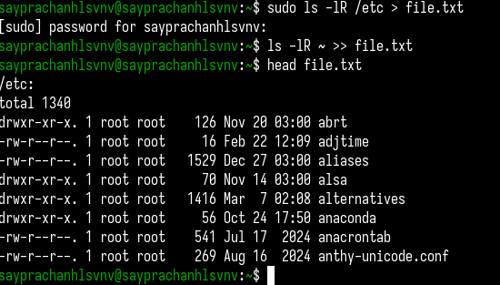

Перечисление и перенаправление файлов

## Перенаправление файла

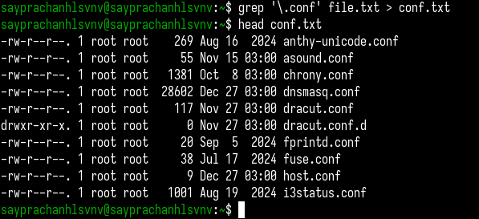

Перенаправление файла

## Поиск файлов

Я нахожу все файлы в домашнем каталоге, начинающиеся на букву ‘c’, используя команду find с опцией -name и шаблоном ’c*’, а затем вывожу их с помощью опции -print.

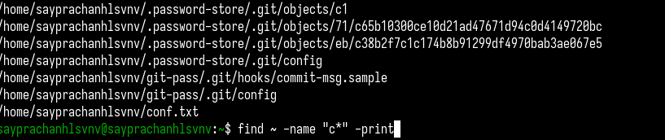

Поиск файла

## Поиск файлов

Другой способ — использовать команду ls вместе с grep, но это работает только для файлов непосредственно в домашнем каталоге, а не в его подкаталогах.

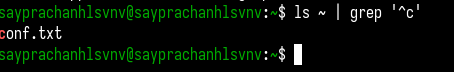

Поиск файла

## Поиск файлов

Далее, используя команду ls, я вывожу список файлов в каталоге /etc, затем с помощью grep нахожу файлы, начинающиеся на букву ‘h’, добавляя строку ‘^h’ (символ ^ означает начало строки).

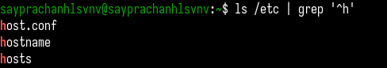

Поиск файла

## Перенаправление файла

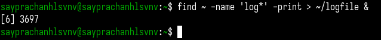

Поиск и перенаправление файлов

## Удаление файла

Я удаляю файл ~/logfile с помощью команды rm.

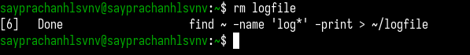

Удаление файла

## Работает в фоновом режиме

Я запускаю gedit из консоли в фоновом режиме, используя амперсанд (&).

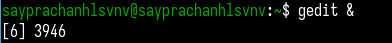

Запуск программы в фоновом режиме

## Процесс ID

Я получаю информацию о процессах, запущенных в моём терминале, с помощью команды ps с опцией aux, затем с помощью grep ищу процесс gedit, чтобы узнать его ID (PID). Также можно использовать команду pgrep gedit, которая также выведет ID процесса.

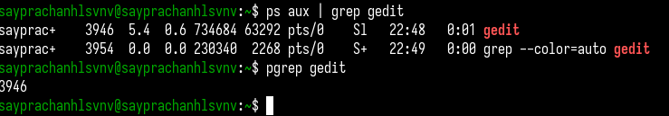

Информация о процессе ID

## Инструкции по командам

Используя команду man, я читаю инструкцию к команде kill, затем, используя полученную информацию, завершаю процесс gedit с помощью команды kill и его PID (например, 3946).

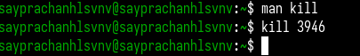

Завершающие процессы

## Инструкции по командам

Перед выполнением команд я читаю инструкции к командам df и du с помощью man.

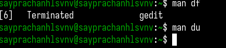

Инструкции о командах

## Информация о диске

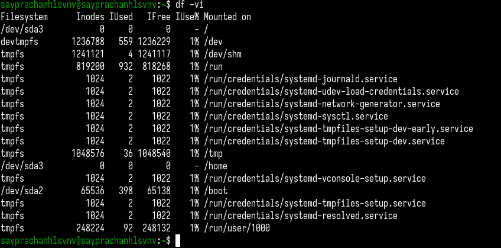

## Информация о диске

Затем, используя команду du, я вывожу информацию об использовании диска для всех файлов в каталоге. Я указываю каталог lab03/report, где хранятся файлы лабораторной работы 3.

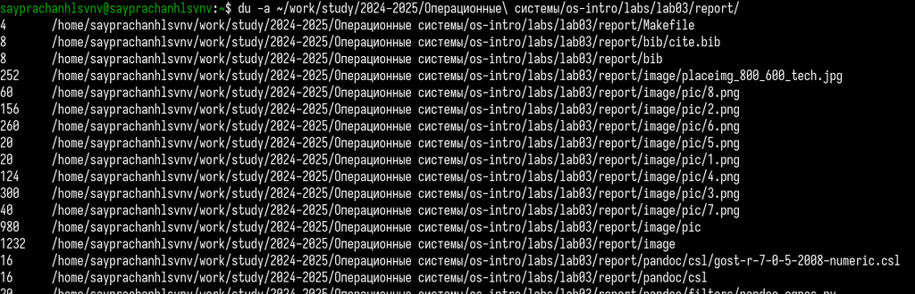

Информация об использовании диска

## Поиск файлов

Я нахожу все каталоги в домашней директории с помощью команды find, устанавливая параметр -type в значение d (от “directory”).

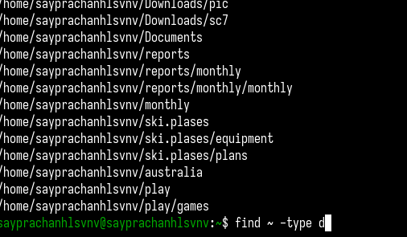

Поиск всех каталогов

## Выводы

Во время этой лабораторной работы, я ознакомился с инструментами поиска файлов и фильтрации текстовых данных. Приобрел практические навыки управления процессами (и задачами), проверки использования диска и обслуживания файловых систем.

# Спасибо за внимание